# Predictive Modeling of COVID-19 Outcomes

Shubham Kamboj (DSTC-22/23-014)

2023-05-29

**Reading CSV file from System**

```r
 #rm(list= ls())

start_time <- Sys.time()

library(Boruta)
library(mlbench)
library(caret)
library(randomForest)
```

```r
library(caTools)
library(e1071)
library(ggplot2)
```

```r
data<- read.csv("C:/Users/USER/OneDrive - students.sau.ac.in/Desktop/Rfiles/University Project on Covid19/covid.csv")

# str(data)
```

**factoring variables which are multicategorical**

```r
columns_to_factor <- c("sex","coronaseve","obesity","htn","dm","cad",
                       "copd","ckd","cva","lvdys","asthma","copd1","tb",
                       "malignancy","typeofmali","liverillne","fever",
                       "cough","dyspnoea","diarrhea","nauseavom","gitcomp",
                       "respirator","anemia","throbocyto","lft","sgot","sgpt",
                       "aki","abgacidos","ddimer","serumfibri","sferrtin",
                       "il6","lqtinter","sinustachy","arrhythmia","supreavent",
                       "pac","mat","at","af0","afl","psvt","ventricula", "vpc",
                       "nonsusvt"   ,"sustvt","vf","bradyarrhy","firstdegav",
                       "seconavblo", "thirdavblo" ,"oxygenrequ","cxrpneu",
                       "patchprsen","patchlobel", "pleuraleff", "oxygenreq1",
                       "ventilator", "noninvasie", "invasive" ,  "arrythmia" ,
                       "icushift",   "death", "lmwh","ramdesevir" ,"steroid" ,
                       "sitetb" , "sarsseveri" , "cadtype", "patchside" ,
                       "lmwhdoseus", "ntprobnp", "tropt" , "sars",
                       "coviddeath", "noncovidde" , "procovidde", "discharge")
# colnames(data)


for(i in columns_to_factor){
  data[,i] <- factor(data[,i])
}

#summary(data)
```

**counts of NA’s**

*Count of missing values patient wise*

```r
data_sno <- cbind(sno = 1:nrow(data) , data)


# loop to count the missing values for each row

p_na_count<-c() # this is empty vector which will store count of NA's
for (i in 1:nrow(data_sno)){
  x<-0
  for(j in 1:ncol(data_sno)){
    if(is.na(data_sno[i,j]) == T){
      x <- x + 1
    }
    p_na_count[i] <- x
  }
}

na_count_p <- cbind(pt_sno = data_sno[,1] , total_na = p_na_count)
NA_count_p <- na_count_p[ order(-p_na_count) ,  ] # ordering of p_na_count
head(NA_count_p , 40)
```

```
##       pt_sno total_na
##  [1,]     40       36
##  [2,]     43       36
##  [3,]     64       31
##  [4,]     69       31
##  [5,]     26       29
##  [6,]     27       29
##  [7,]     28       28
##  [8,]     13       26
##  [9,]      8       24
## [10,]      9       24
## [11,]     23       24
## [12,]     32       24
## [13,]     36       24
## [14,]     39       23
```

[output cut: 26 more lines]

```r
g <- NA_count_p[1:36 , 1] # refer NA_count_p to find number 36
# g contains row no of patient having 15 or more attributes missing


data_lna <- data_sno[-g , ]  # droping those patients from study

#write.csv(data_lna , file = "D:\\machine learning materials\\data_lna.csv" )
data<- data_lna[ , -1] # removing sno from the data set
dim(data)
```

```
## [1] 269 111
```

```r
#summary(data)
```

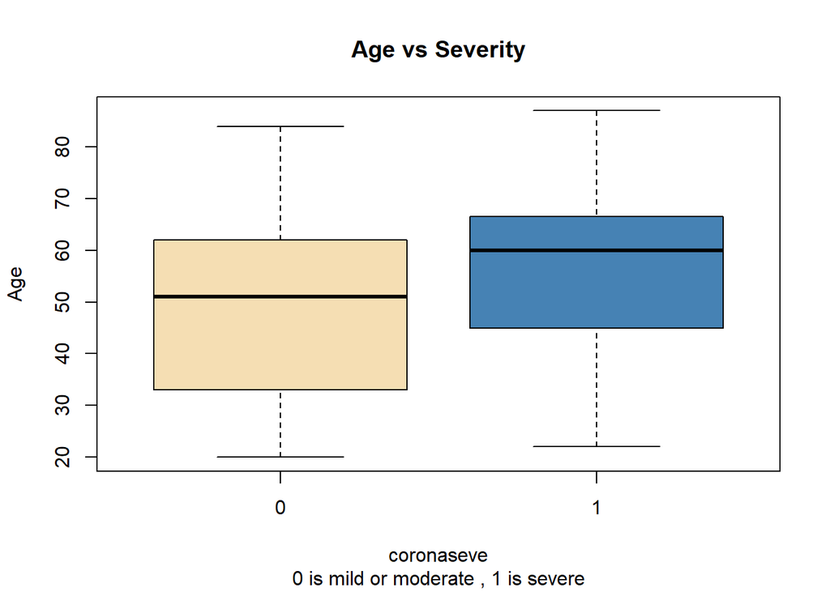

```r
boxplot(data$age ~ data$coronaseve ,
        xlab = "coronaseve" , ylab = "Age" ,
        main = "Age vs Severity" ,
        sub ="0 is mild or moderate , 1 is severe" ,
        col = c("wheat" , "steelblue"))
```

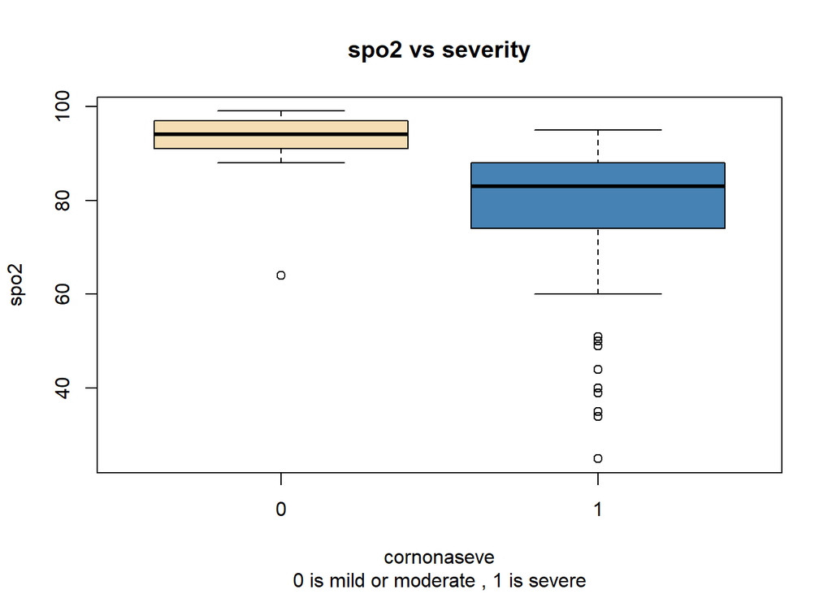

```r
boxplot(data$spo2 ~ data$coronaseve,
        xlab= "cornonaseve" , ylab = "spo2",
        main = "spo2 vs severity" ,
        sub = "0 is mild or moderate , 1 is severe" ,
        col = c("wheat" , "steelblue"))
```

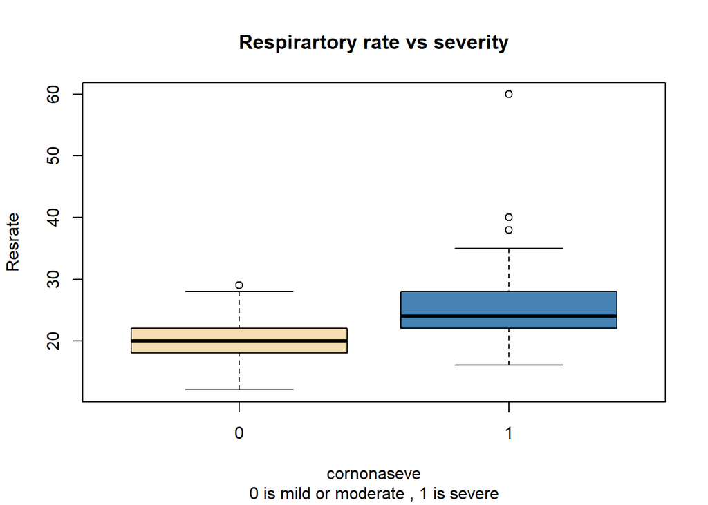

```r
boxplot(data$resrate ~ data$coronaseve,
        xlab= "cornonaseve" , ylab = "Resrate",
        main = "Respirartory rate vs severity" ,
        sub = "0 is mild or moderate , 1 is severe" ,
        col = c("wheat" , "steelblue"))
```

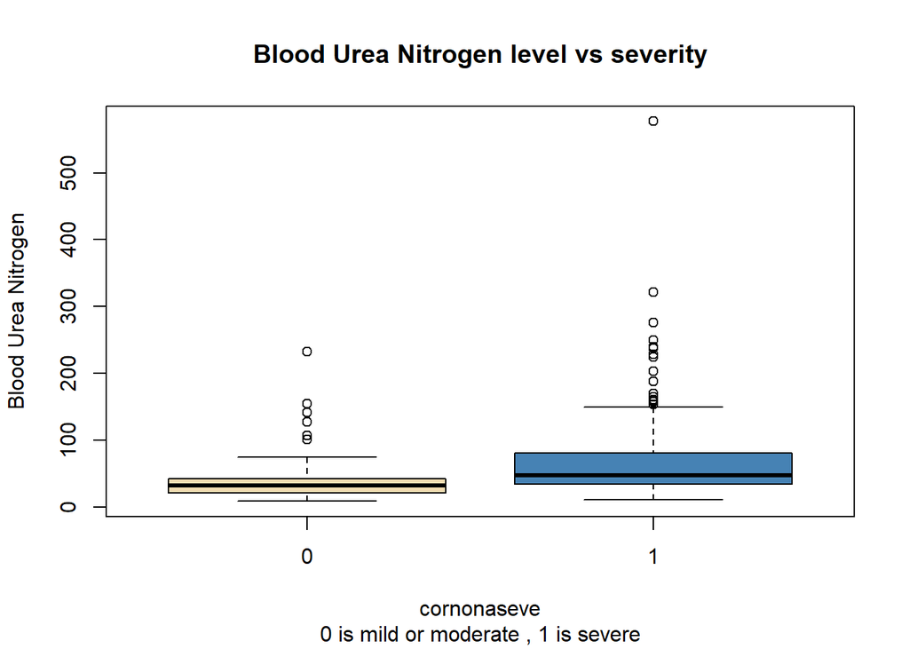

```r
boxplot(data$bun ~ data$coronaseve,
        xlab= "cornonaseve" , ylab = "Blood Urea Nitrogen",
        main = "Blood Urea Nitrogen level vs severity" ,
        sub = "0 is mild or moderate , 1 is severe" ,
        col = c("wheat" , "steelblue"))
```

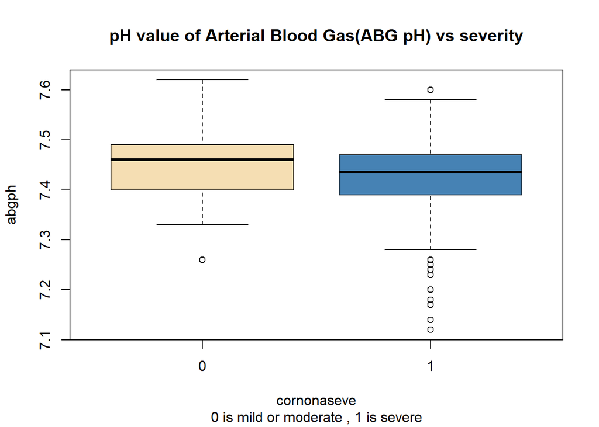

```r
boxplot(data$abgph ~ data$coronaseve,
        xlab= "cornonaseve" , ylab = "abgph",
        main = "pH value of Arterial Blood Gas(ABG pH) vs severity" ,
        sub = "0 is mild or moderate , 1 is severe" ,
        col = c("wheat" , "steelblue"))
```

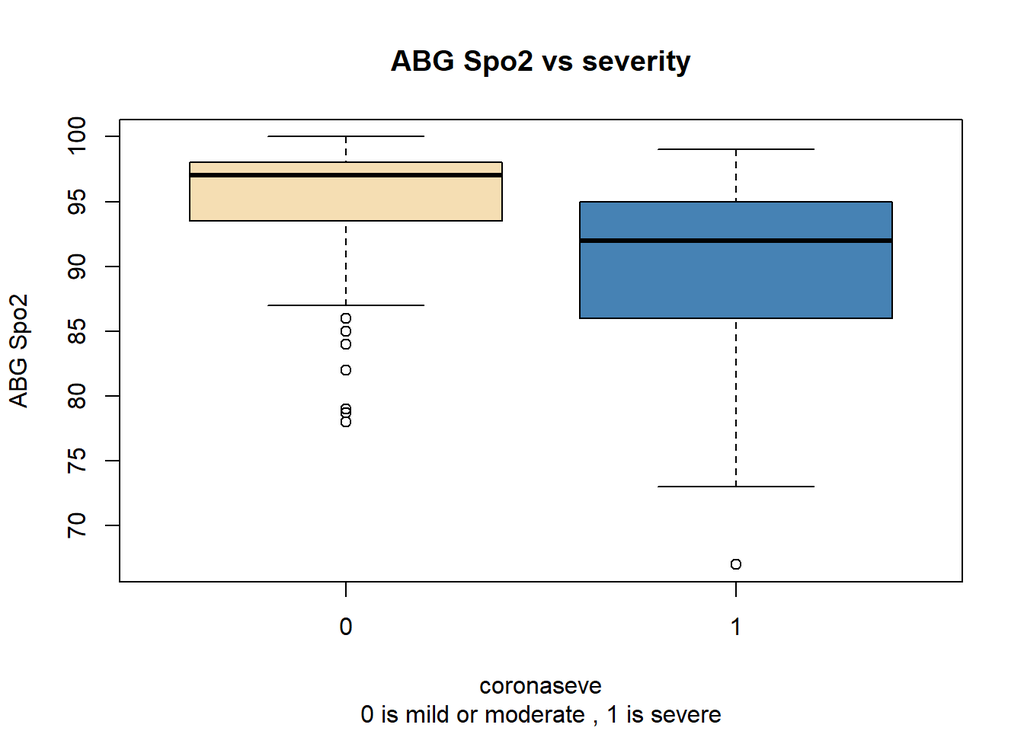

```r
boxplot(data$abgspo2 ~ data$coronaseve,
        xlab= "coronaseve" , ylab = "ABG Spo2",
        main = "ABG Spo2 vs severity" ,
        sub = "0 is mild or moderate , 1 is severe" ,
        col = c("wheat" , "steelblue"))
```

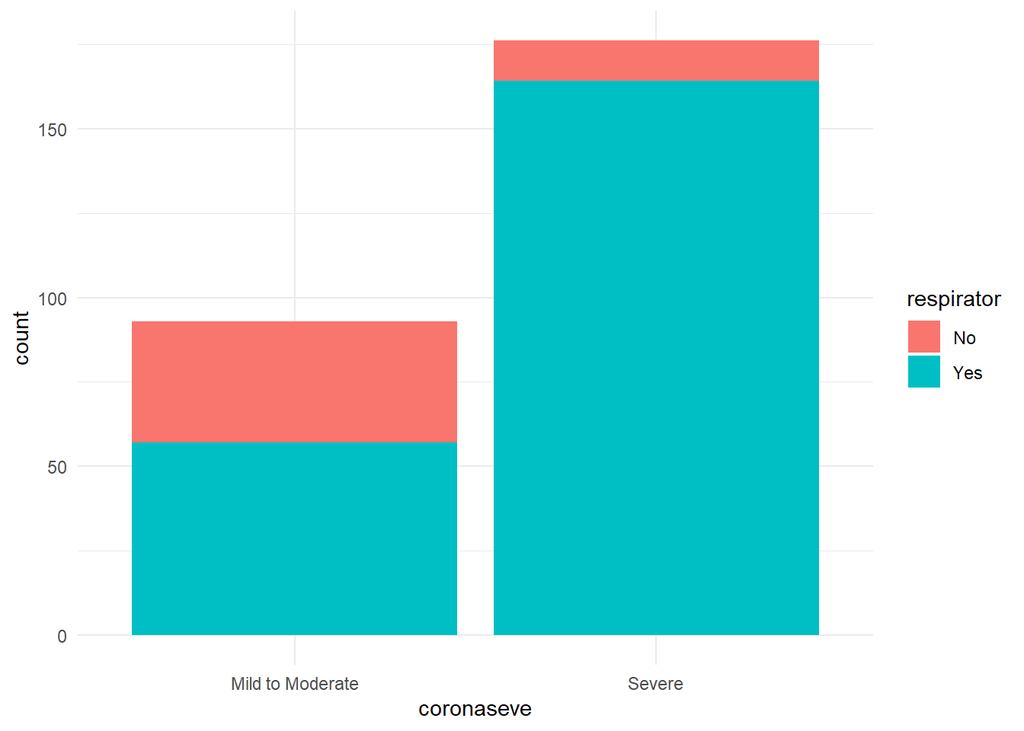

```r
# Create a bar plot using ggplot between coronaseve & respirator
ggplot(data, aes(x = coronaseve, fill =   respirator)) +
     geom_bar() +
     labs(x = "coronaseve", fill = "respirator") +
     scale_x_discrete(labels = c("Mild to Moderate", "Severe")) +
     scale_fill_discrete(labels = c("No", "Yes")) +
     theme_minimal()
```

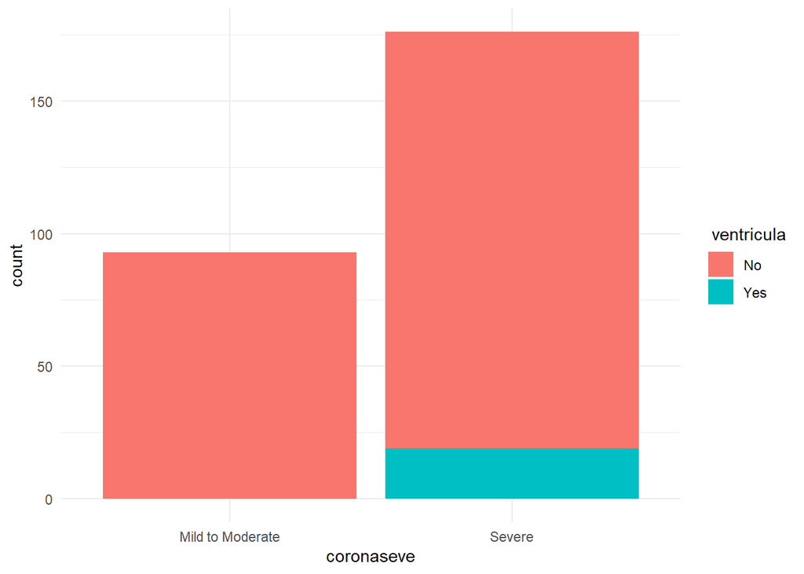

```r
# Create a bar plot using ggplot between coronaseve &  ventricula
ggplot(data, aes(x = coronaseve, fill =    ventricula)) +
     geom_bar() +
     labs(x = "coronaseve", fill = " ventricula") +
     scale_x_discrete(labels = c("Mild to Moderate", "Severe")) +
     scale_fill_discrete(labels = c("No", "Yes")) +
     theme_minimal()
```

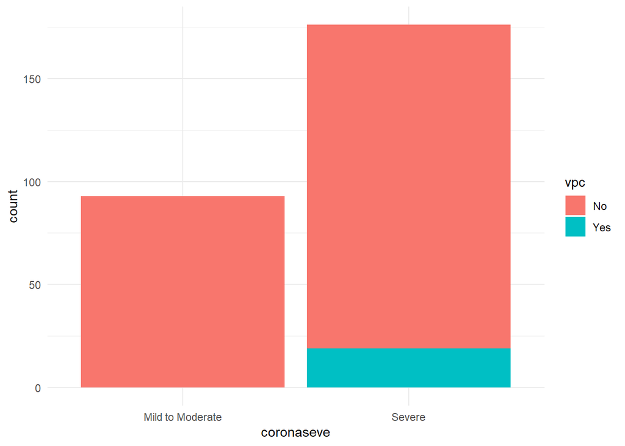

```r
# Create a bar plot using ggplot between coronaseve &  vpc
ggplot(data, aes(x = coronaseve, fill =    vpc)) +
     geom_bar() +
     labs(x = "coronaseve", fill = "vpc") +
     scale_x_discrete(labels = c("Mild to Moderate", "Severe")) +
     scale_fill_discrete(labels = c("No", "Yes")) +
     theme_minimal()
```

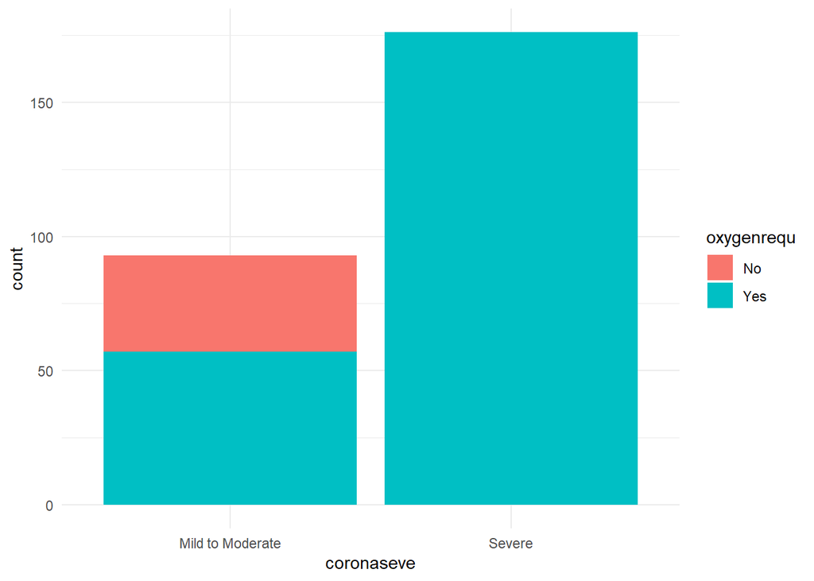

```r
# Create a bar plot using ggplot between coronaseve &  oxygenrequ
ggplot(data, aes(x = coronaseve, fill =    oxygenrequ)) +
     geom_bar() +
     labs(x = "coronaseve", fill = "oxygenrequ") +
     scale_x_discrete(labels = c("Mild to Moderate", "Severe")) +
     scale_fill_discrete(labels = c("No", "Yes")) +
     theme_minimal()
```

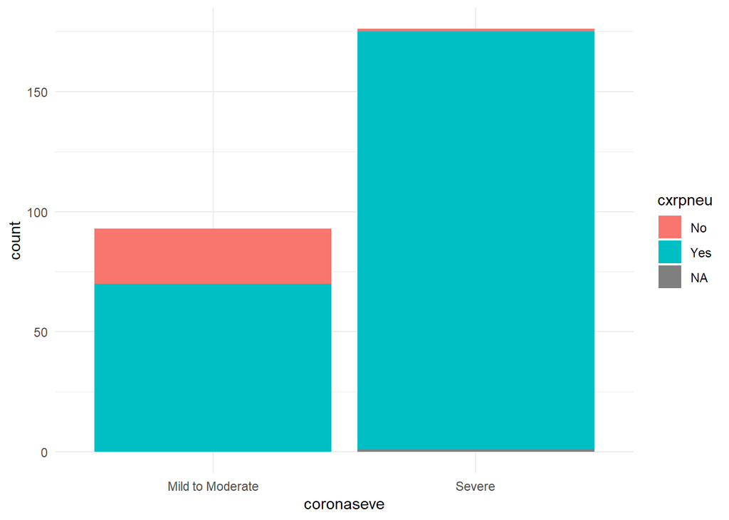

```r
# Create a bar plot using ggplot between coronaseve &  cxrpneu
ggplot(data, aes(x = coronaseve, fill =    cxrpneu)) +
     geom_bar() +
     labs(x = "coronaseve", fill = "cxrpneu") +
     scale_x_discrete(labels = c("Mild to Moderate", "Severe")) +
     scale_fill_discrete(labels = c("No", "Yes")) +
     theme_minimal()
```

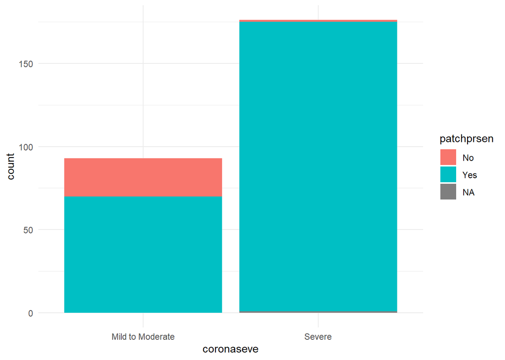

```r
# Create a bar plot using ggplot between coronaseve &  patchprsen
ggplot(data, aes(x = coronaseve, fill =    patchprsen)) +
     geom_bar() +
     labs(x = "coronaseve", fill = "patchprsen") +
     scale_x_discrete(labels = c("Mild to Moderate", "Severe")) +
     scale_fill_discrete(labels = c("No", "Yes")) +
     theme_minimal()
```

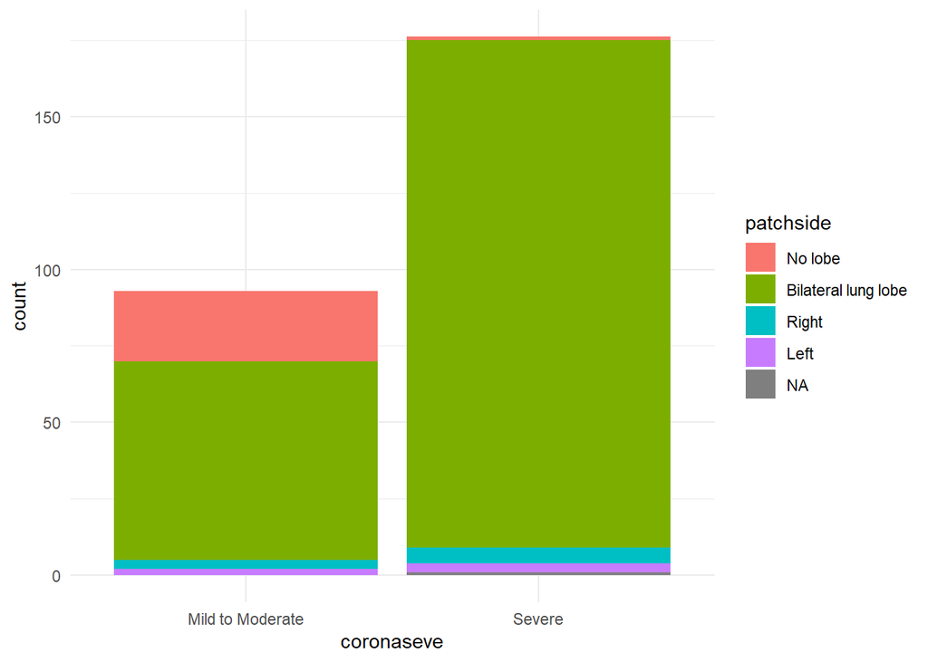

```r
# Create a bar plot using ggplot between coronaseve &  patchside
ggplot(data, aes(x = coronaseve, fill =    patchside)) +
     geom_bar() +
     labs(x = "coronaseve", fill = "patchside") +
     scale_x_discrete(labels = c("Mild to Moderate", "Severe")) +
     scale_fill_discrete(labels = c("No lobe", "Bilateral lung lobe",
                                    "Right", "Left")) +
     theme_minimal()
```

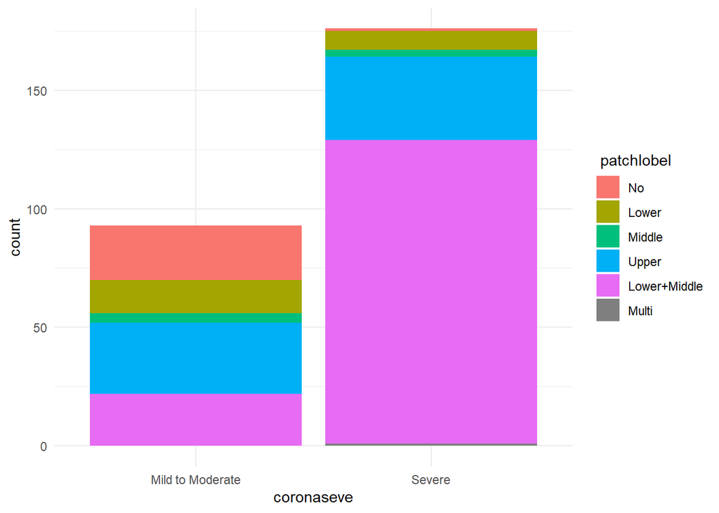

```r
# Create a bar plot using ggplot between coronaseve &  patchlobel
ggplot(data, aes(x = coronaseve, fill =    patchlobel)) +
     geom_bar() +
     labs(x = "coronaseve", fill = " patchlobel") +
     scale_x_discrete(labels = c("Mild to Moderate", "Severe")) +
     scale_fill_discrete(labels = c("No", "Lower","Middle","Upper",
                                    "Lower+Middle" ,"Multi")) +
     theme_minimal()
```

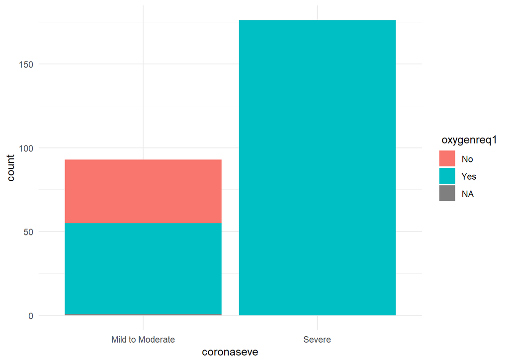

```r
# Create a bar plot using ggplot between coronaseve &  oxygenreq1
ggplot(data, aes(x = coronaseve, fill =    oxygenreq1)) +
     geom_bar() +
     labs(x = "coronaseve", fill = " oxygenreq1") +
     scale_x_discrete(labels = c("Mild to Moderate", "Severe")) +
     scale_fill_discrete(labels = c("No", "Yes")) +
     theme_minimal()
```

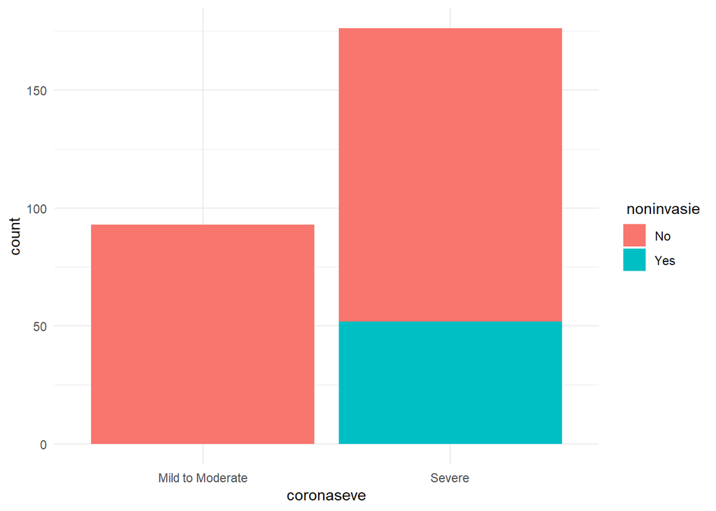

```r
# Create a bar plot using ggplot between coronaseve &  noninvasie
ggplot(data, aes(x = coronaseve, fill =    noninvasie)) +
     geom_bar() +
     labs(x = "coronaseve", fill = " noninvasie") +
     scale_x_discrete(labels = c("Mild to Moderate", "Severe")) +
     scale_fill_discrete(labels = c("No", "Yes")) +
     theme_minimal()
```

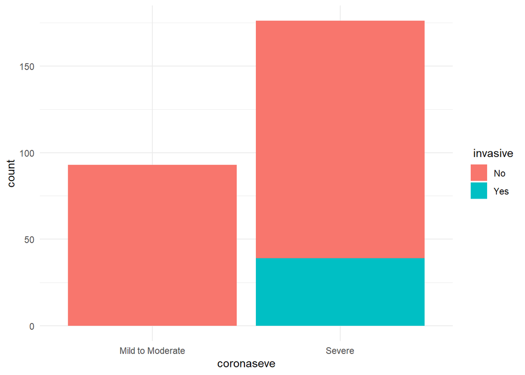

```r
# Create a bar plot using ggplot between coronaseve &  invasive
ggplot(data, aes(x = coronaseve, fill =    invasive)) +
     geom_bar() +
     labs(x = "coronaseve", fill = " invasive") +
     scale_x_discrete(labels =c("Mild to Moderate", "Severe")) +
     scale_fill_discrete(labels = c("No", "Yes")) +
     theme_minimal()
```

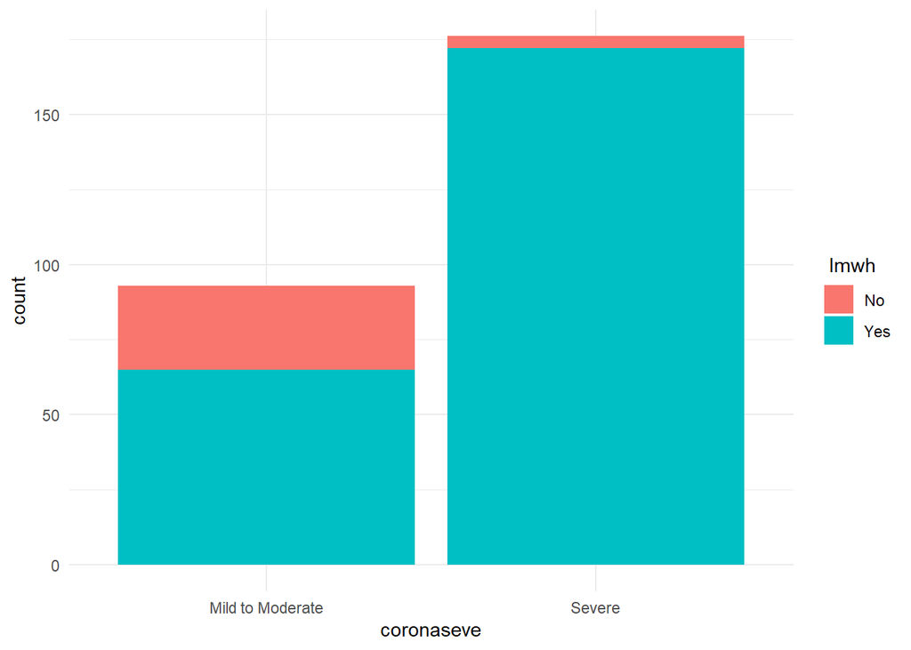

```r
# Create a bar plot using ggplot between coronaseve &  lmwh
ggplot(data, aes(x = coronaseve, fill =    lmwh )) +
     geom_bar() +
     labs(x = "coronaseve", fill = " lmwh ") +
     scale_x_discrete(labels = c("Mild to Moderate", "Severe")) +
     scale_fill_discrete(labels = c("No", "Yes")) +
     theme_minimal()
```

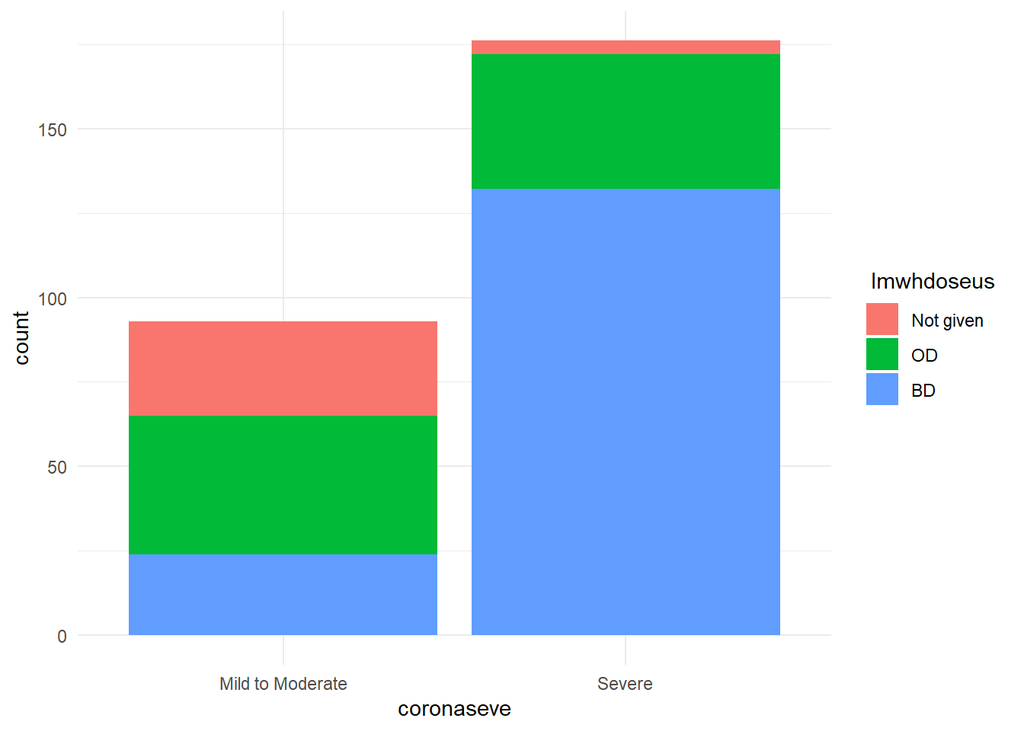

```r
# Create a bar plot using ggplot between coronaseve &  lmwhdoseus
ggplot(data, aes(x = coronaseve, fill =    lmwhdoseus )) +
     geom_bar() +
     labs(x = "coronaseve", fill = " lmwhdoseus ") +
     scale_x_discrete(labels = c("Mild to Moderate", "Severe")) +
     scale_fill_discrete(labels = c("Not given", "OD", "BD")) +
     theme_minimal()
```

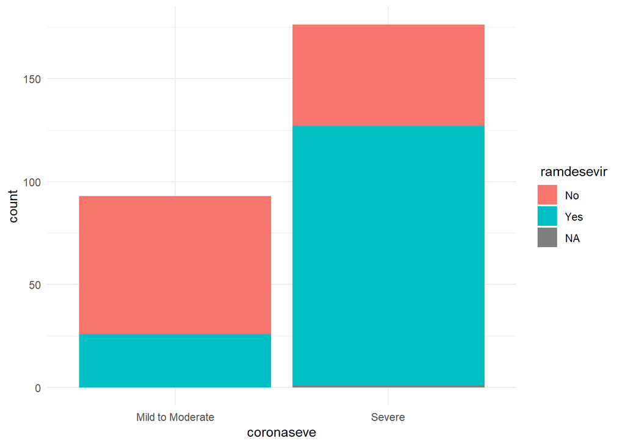

```r
# Create a bar plot using ggplot between coronaseve &  ramdesevir
ggplot(data, aes(x = coronaseve, fill =    ramdesevir )) +
     geom_bar() +
     labs(x = "coronaseve", fill = " ramdesevir ") +
     scale_x_discrete(labels = c("Mild to Moderate", "Severe")) +
     scale_fill_discrete(labels = c("No", "Yes")) +
     theme_minimal()
```

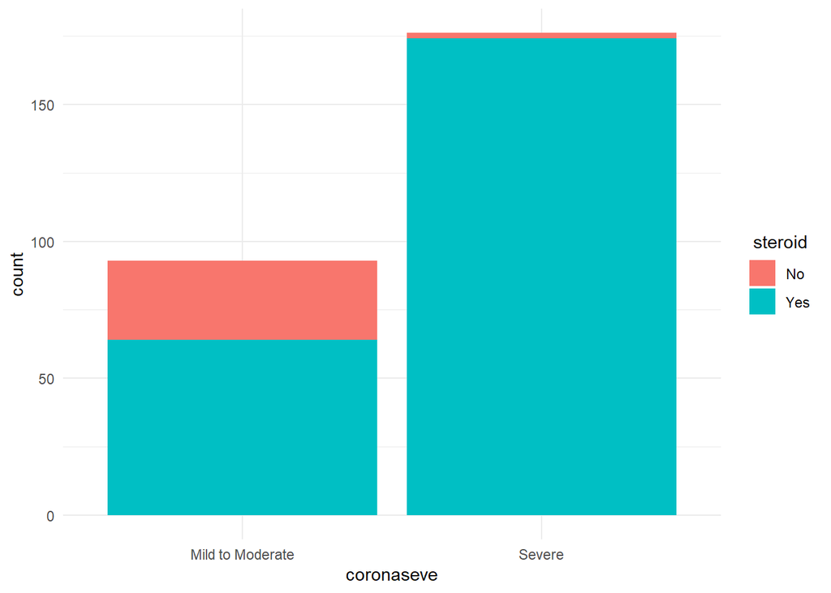

```r
# Create a bar plot using ggplot between coronaseve &  steroid
ggplot(data, aes(x = coronaseve, fill =    steroid )) +
     geom_bar() +
     labs(x = "coronaseve", fill = " steroid ") +
     scale_x_discrete(labels = c("Mild to Moderate", "Severe")) +
     scale_fill_discrete(labels = c("No", "Yes")) +
     theme_minimal()
```

**Count of missing values predictor wise**

```r
a<-colnames(data)
na_count<-rep(NA,ncol(data))
for (i in 1:ncol(data)){
  na_count[i]<- sum(is.na(data[,i]))
}
na<-cbind(a , na_count)
na<-na[order(-na_count) , ]
## Arranging na_counts in descending order
## and suffling corresponding a's as well
NA_count<- na[which(na[,2] != 0) , ]
NA_count
```

```
##       a            na_count
##  [1,] "hba1c"      "205"
##  [2,] "obesity"    "139"
##  [3,] "bmi"        "129"
##  [4,] "ht"         "128"
##  [5,] "weig"       "126"
##  [6,] "pao2fio2"   "40"
##  [7,] "sars"       "39"
##  [8,] "sarsseveri" "39"
##  [9,] "tropt"      "34"
## [10,] "tropt1"     "33"
## [11,] "ntprobnp"   "31"
## [12,] "ntprobnp1"  "31"
## [13,] "abgspo2"    "19"
## [14,] "serumfibri" "19"
```

[output cut: 39 more lines]

```r
dim(NA_count)
```

```
## [1] 53  2
```

```r
# NA_count gives us information about no of NA in given variable
```

**Imputing *Height(ht)* and *Weight (weig)* of Patient assuming Normal** **Distribution and doing Random sampling from distribution of observed data**

```r
data_imputed <- data
# dim(data_imputed)
#
# ## trying to omit observations with missing values
na_omit_data <- na.omit(data)
dim(na_omit_data)
```

```
## [1]  15 111
```

```r
print("Height and Weight can be assumed Normally Distributed")
```

```
## [1] "Height and Weight can be assumed Normally Distributed"
```

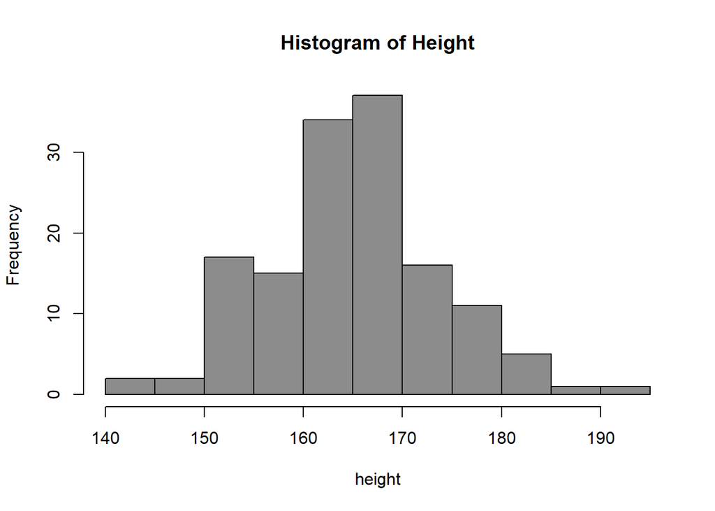

```r
hist(data$ht , main = "Histogram of Height" , col = "gray55" , border = T,
     xlab= "height")
```

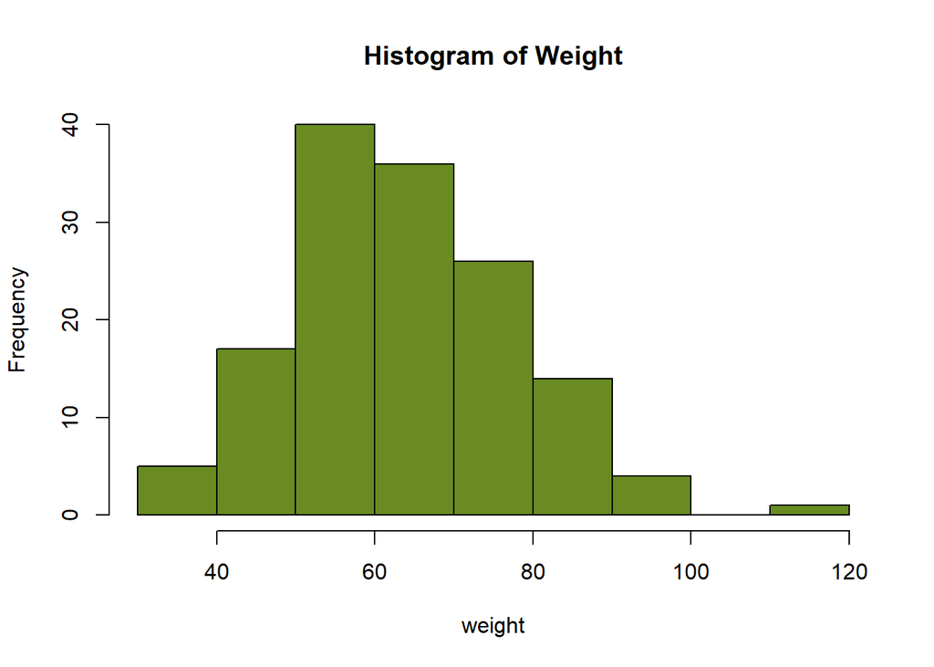

```r
hist(data$weig, main = "Histogram of Weight", col = "olivedrab4" , border = T,
     xlab = "weight")
```

```r
rnormimpfun <- function(x){
  # makinga subset of x, to remove the effect of any potential outlier
  y <- subset(x ,
              x > quantile(x , 0.25 , na.rm = T) ,
              x < quantile(x , 0.75 , na.rm = T))

 for(i in 1:length(x)){
   if(is.na(x[i]) == TRUE ){
     x[i] <- round( rnorm(1, mean=mean(y , na.rm = T), sd=sd(y) ), 2)

    }
  }
  return(x)
}


summary(data$ht)
```

```
##    Min. 1st Qu.  Median    Mean 3rd Qu.    Max.    NA's
##   142.2   160.0   165.1   164.4   168.0   190.5     128
```

**Imputation of Height**

```r
data_imputed$ht <- rnormimpfun(data$ht)

# ## Summary of height (ht) after imputation
# summary(data_imputed$ht)
#
# ## summary of height before imputation
# summary(data$ht)
```

**Imputation of weight**

```r
#summary(data$weig)

data_imputed$weig <- rnormimpfun(data$weig)

# ## Summary of weight (weig) after imputation
# summary(data_imputed$weig)
#
# ## Summary of weight (weig) before imputation
# summary(data$weig)
```

**Impuation of BMI**

```r
for (i in 1:length(data_imputed$bmi)){
  if (is.na(data_imputed$bmi[i]) == T){
    data_imputed$bmi[i] <- (data_imputed$weig[i]/(data_imputed$ht[i]/100)^2)
  }
}


# ## Summary of bmi (bmi) after imputation
# summary(data_imputed$bmi)
#
# ## Summary of bmi (bmi) before imputation
# summary(data$bmi)
#
#
```

**Imputation of obesity, based on bmi calculation**

```r
#
for( i in 1:length(data$obesity ) ){
  if(is.na(data$obesity[i]) == T ){
    if(data_imputed$bmi[i] >= 25 ){
      data_imputed$obesity[i] <- 1
    }else{data_imputed$obesity[i] <- 0}
  }
}
```